# Optimal Treatment Analysis

## Outcome Variable

**Outcome Variable:** ever_stunted

## Predictor Variables

**Intervention Variable:** nhh

**Adjustment Set:**

- arm
- W_mage
- meducyrs
- feducyrs
- W_mhtcm
- W_mwtkg
- W_mbmi
- W_nrooms
- impfloor
- impsan
- safeh20
- delta_W_mage
- delta_meducyrs
- delta_feducyrs
- delta_W_mhtcm
- delta_W_mwtkg
- delta_W_mbmi
- delta_W_nrooms
- delta_impfloor
- delta_impsan
- delta_safeh20

## Stratifying Variables

The analysis was stratified on these variable(s):

- agecat
- studyid
- country

## Data Summary

| agecat | studyid | country | nhh | ever_stunted | n_cell | n |
| --- | --- | --- | --- | --- | --- | --- |
| 0-24 months | ki1000108-IRC | INDIA | 3 or less | 0 | 25 | 410 |
| 0-24 months | ki1000108-IRC | INDIA | 3 or less | 1 | 33 | 410 |
| 0-24 months | ki1000108-IRC | INDIA | 4-5 | 0 | 52 | 410 |
| 0-24 months | ki1000108-IRC | INDIA | 4-5 | 1 | 106 | 410 |
| 0-24 months | ki1000108-IRC | INDIA | 6-7 | 0 | 41 | 410 |
| 0-24 months | ki1000108-IRC | INDIA | 6-7 | 1 | 66 | 410 |
| 0-24 months | ki1000108-IRC | INDIA | 8+ | 0 | 29 | 410 |
| 0-24 months | ki1000108-IRC | INDIA | 8+ | 1 | 58 | 410 |
| 0-24 months | ki1000304b-SAS-FoodSuppl | INDIA | 3 or less | 0 | 9 | 418 |
| 0-24 months | ki1000304b-SAS-FoodSuppl | INDIA | 3 or less | 1 | 29 | 418 |
| 0-24 months | ki1000304b-SAS-FoodSuppl | INDIA | 4-5 | 0 | 35 | 418 |
| 0-24 months | ki1000304b-SAS-FoodSuppl | INDIA | 4-5 | 1 | 148 | 418 |
| 0-24 months | ki1000304b-SAS-FoodSuppl | INDIA | 6-7 | 0 | 16 | 418 |
| 0-24 months | ki1000304b-SAS-FoodSuppl | INDIA | 6-7 | 1 | 111 | 418 |
| 0-24 months | ki1000304b-SAS-FoodSuppl | INDIA | 8+ | 0 | 12 | 418 |
| 0-24 months | ki1000304b-SAS-FoodSuppl | INDIA | 8+ | 1 | 58 | 418 |
| 0-24 months | ki1017093-NIH-Birth | BANGLADESH | 3 or less | 0 | 47 | 629 |
| 0-24 months | ki1017093-NIH-Birth | BANGLADESH | 3 or less | 1 | 70 | 629 |
| 0-24 months | ki1017093-NIH-Birth | BANGLADESH | 4-5 | 0 | 77 | 629 |
| 0-24 months | ki1017093-NIH-Birth | BANGLADESH | 4-5 | 1 | 187 | 629 |
| 0-24 months | ki1017093-NIH-Birth | BANGLADESH | 6-7 | 0 | 42 | 629 |
| 0-24 months | ki1017093-NIH-Birth | BANGLADESH | 6-7 | 1 | 100 | 629 |
| 0-24 months | ki1017093-NIH-Birth | BANGLADESH | 8+ | 0 | 45 | 629 |
| 0-24 months | ki1017093-NIH-Birth | BANGLADESH | 8+ | 1 | 61 | 629 |
| 0-24 months | ki1017093b-PROVIDE | BANGLADESH | 3 or less | 0 | 83 | 700 |
| 0-24 months | ki1017093b-PROVIDE | BANGLADESH | 3 or less | 1 | 57 | 700 |
| 0-24 months | ki1017093b-PROVIDE | BANGLADESH | 4-5 | 0 | 179 | 700 |
| 0-24 months | ki1017093b-PROVIDE | BANGLADESH | 4-5 | 1 | 143 | 700 |
| 0-24 months | ki1017093b-PROVIDE | BANGLADESH | 6-7 | 0 | 84 | 700 |
| 0-24 months | ki1017093b-PROVIDE | BANGLADESH | 6-7 | 1 | 67 | 700 |

[output cut: 114 more lines]

The following strata were considered:

- agecat: 0-24 months, studyid: ki1000108-IRC, country: INDIA
- agecat: 0-24 months, studyid: ki1000304b-SAS-FoodSuppl, country: INDIA
- agecat: 0-24 months, studyid: ki1017093-NIH-Birth, country: BANGLADESH
- agecat: 0-24 months, studyid: ki1017093b-PROVIDE, country: BANGLADESH
- agecat: 0-24 months, studyid: ki1017093c-NIH-Crypto, country: BANGLADESH
- agecat: 0-24 months, studyid: ki1148112-LCNI-5, country: MALAWI
- agecat: 0-6 months, studyid: ki1000108-IRC, country: INDIA
- agecat: 0-6 months, studyid: ki1000304b-SAS-FoodSuppl, country: INDIA
- agecat: 0-6 months, studyid: ki1017093-NIH-Birth, country: BANGLADESH
- agecat: 0-6 months, studyid: ki1017093b-PROVIDE, country: BANGLADESH
- agecat: 0-6 months, studyid: ki1017093c-NIH-Crypto, country: BANGLADESH
- agecat: 0-6 months, studyid: ki1148112-LCNI-5, country: MALAWI
- agecat: 6-24 months, studyid: ki1000108-IRC, country: INDIA
- agecat: 6-24 months, studyid: ki1000304b-SAS-FoodSuppl, country: INDIA
- agecat: 6-24 months, studyid: ki1017093-NIH-Birth, country: BANGLADESH
- agecat: 6-24 months, studyid: ki1017093b-PROVIDE, country: BANGLADESH
- agecat: 6-24 months, studyid: ki1017093c-NIH-Crypto, country: BANGLADESH
- agecat: 6-24 months, studyid: ki1148112-LCNI-5, country: MALAWI

### Dropped Strata

Some strata were dropped due to rare outcomes:

- agecat: 0-6 months, studyid: ki1148112-LCNI-5, country: MALAWI

## Methods Detail

We’re interested in the causal parameters $E[Y_a]$ for all values of $a \in \mathcal{A}$. These parameters represent the mean outcome if, possibly contrary to fact, we intervened to set all units to have $A=a$. Under the randomization and positivity assumptions, these are identified by the statistical parameters $\psi_a=E_W[E_{Y|A,W}(Y|A=a,W)]$. In addition, we’re interested in the mean of $Y$, $E[Y]$ under no intervention (the observed mean). We will estimate these parameters by using SuperLearner to fit the relevant likelihood factors – $E_{Y|A,W}(Y|A=a,W)$ and $p(A=a|W)$, and then updating our likelihood fit using a joint TMLE.

For unadjusted analyses ($W=\{\}$), initial likelihoods were estimated using Lrnr_glm to estimate the simple $E(Y|A)$ and Lrnr_mean to estimate $p(A)$. For adjusted analyses, a small library containing Lrnr_glmnet, Lrnr_xgboost, and Lrnr_mean was used.

Having estimated these parameters, we will then use the delta method to estimate relative risks and attributable risks relative to a prespecified baseline level of $A$.

# Results Detail

## Results Plots

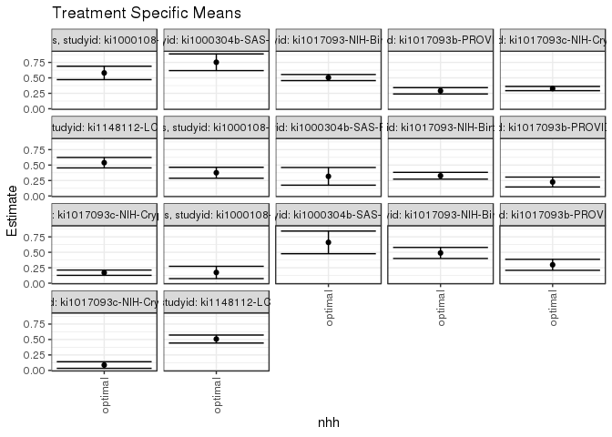

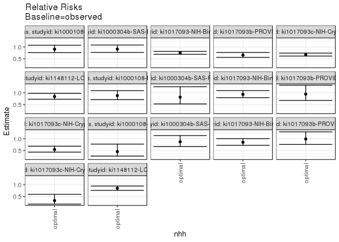

## Results Table

### Parameter: TSM

| agecat | studyid | country | intervention_level | baseline_level | estimate | ci_lower | ci_upper |
| --- | --- | --- | --- | --- | --- | --- | --- |
| 0-24 months | ki1000108-IRC | INDIA | optimal | NA | 0.5800671 | 0.4714621 | 0.6886720 |
| 0-24 months | ki1000304b-SAS-FoodSuppl | INDIA | optimal | NA | 0.7527726 | 0.6173999 | 0.8881452 |
| 0-24 months | ki1017093-NIH-Birth | BANGLADESH | optimal | NA | 0.5051482 | 0.4556964 | 0.5545999 |
| 0-24 months | ki1017093b-PROVIDE | BANGLADESH | optimal | NA | 0.2907001 | 0.2396893 | 0.3417110 |
| 0-24 months | ki1017093c-NIH-Crypto | BANGLADESH | optimal | NA | 0.3271595 | 0.2927301 | 0.3615890 |
| 0-24 months | ki1148112-LCNI-5 | MALAWI | optimal | NA | 0.5385370 | 0.4540368 | 0.6230373 |
| 0-6 months | ki1000108-IRC | INDIA | optimal | NA | 0.3757687 | 0.2869554 | 0.4645819 |
| 0-6 months | ki1000304b-SAS-FoodSuppl | INDIA | optimal | NA | 0.3176913 | 0.1745106 | 0.4608719 |
| 0-6 months | ki1017093-NIH-Birth | BANGLADESH | optimal | NA | 0.3271975 | 0.2722163 | 0.3821788 |
| 0-6 months | ki1017093b-PROVIDE | BANGLADESH | optimal | NA | 0.2259198 | 0.1457048 | 0.3061348 |
| 0-6 months | ki1017093c-NIH-Crypto | BANGLADESH | optimal | NA | 0.1696974 | 0.1267820 | 0.2126129 |
| 6-24 months | ki1000108-IRC | INDIA | optimal | NA | 0.1734087 | 0.0735191 | 0.2732983 |
| 6-24 months | ki1000304b-SAS-FoodSuppl | INDIA | optimal | NA | 0.6605638 | 0.4773037 | 0.8438239 |
| 6-24 months | ki1017093-NIH-Birth | BANGLADESH | optimal | NA | 0.4893412 | 0.4001314 | 0.5785510 |
| 6-24 months | ki1017093b-PROVIDE | BANGLADESH | optimal | NA | 0.2975172 | 0.2085935 | 0.3864410 |
| 6-24 months | ki1017093c-NIH-Crypto | BANGLADESH | optimal | NA | 0.0866299 | 0.0333733 | 0.1398865 |
| 6-24 months | ki1148112-LCNI-5 | MALAWI | optimal | NA | 0.5074757 | 0.4427317 | 0.5722196 |

### Parameter: E(Y)

| agecat | studyid | country | intervention_level | baseline_level | estimate | ci_lower | ci_upper |
| --- | --- | --- | --- | --- | --- | --- | --- |
| 0-24 months | ki1000108-IRC | INDIA | observed | NA | 0.6422324 | 0.5957553 | 0.6887095 |
| 0-24 months | ki1000304b-SAS-FoodSuppl | INDIA | observed | NA | 0.8276752 | 0.7914335 | 0.8639168 |
| 0-24 months | ki1017093-NIH-Birth | BANGLADESH | observed | NA | 0.6736215 | 0.6366942 | 0.7105487 |
| 0-24 months | ki1017093b-PROVIDE | BANGLADESH | observed | NA | 0.4430921 | 0.4063473 | 0.4798369 |
| 0-24 months | ki1017093c-NIH-Crypto | BANGLADESH | observed | NA | 0.4854742 | 0.4498920 | 0.5210564 |
| 0-24 months | ki1148112-LCNI-5 | MALAWI | observed | NA | 0.6377539 | 0.6047742 | 0.6707335 |
| 0-6 months | ki1000108-IRC | INDIA | observed | NA | 0.4256887 | 0.3777889 | 0.4735884 |
| 0-6 months | ki1000304b-SAS-FoodSuppl | INDIA | observed | NA | 0.3888257 | 0.3419115 | 0.4357400 |
| 0-6 months | ki1017093-NIH-Birth | BANGLADESH | observed | NA | 0.3501616 | 0.3128631 | 0.3874600 |
| 0-6 months | ki1017093b-PROVIDE | BANGLADESH | observed | NA | 0.2389327 | 0.2073366 | 0.2705288 |
| 0-6 months | ki1017093c-NIH-Crypto | BANGLADESH | observed | NA | 0.3097603 | 0.2770506 | 0.3424700 |
| 6-24 months | ki1000108-IRC | INDIA | observed | NA | 0.3788333 | 0.3168670 | 0.4407996 |
| 6-24 months | ki1000304b-SAS-FoodSuppl | INDIA | observed | NA | 0.7574902 | 0.7034684 | 0.8115120 |
| 6-24 months | ki1017093-NIH-Birth | BANGLADESH | observed | NA | 0.5759811 | 0.5237245 | 0.6282376 |
| 6-24 months | ki1017093b-PROVIDE | BANGLADESH | observed | NA | 0.3004629 | 0.2584110 | 0.3425147 |
| 6-24 months | ki1017093c-NIH-Crypto | BANGLADESH | observed | NA | 0.2645978 | 0.2262066 | 0.3029891 |
| 6-24 months | ki1148112-LCNI-5 | MALAWI | observed | NA | 0.6008967 | 0.5648363 | 0.6369571 |

### Parameter: RR

| agecat | studyid | country | intervention_level | baseline_level | estimate | ci_lower | ci_upper |
| --- | --- | --- | --- | --- | --- | --- | --- |
| 0-24 months | ki1000108-IRC | INDIA | optimal | observed | 0.9032043 | 0.7605913 | 1.0725577 |
| 0-24 months | ki1000304b-SAS-FoodSuppl | INDIA | optimal | observed | 0.9095024 | 0.7672434 | 1.0781385 |
| 0-24 months | ki1017093-NIH-Birth | BANGLADESH | optimal | observed | 0.7498991 | 0.6908606 | 0.8139828 |
| 0-24 months | ki1017093b-PROVIDE | BANGLADESH | optimal | observed | 0.6560716 | 0.5623298 | 0.7654403 |
| 0-24 months | ki1017093c-NIH-Crypto | BANGLADESH | optimal | observed | 0.6738969 | 0.6144693 | 0.7390719 |
| 0-24 months | ki1148112-LCNI-5 | MALAWI | optimal | observed | 0.8444277 | 0.7300250 | 0.9767586 |
| 0-6 months | ki1000108-IRC | INDIA | optimal | observed | 0.8827312 | 0.7137372 | 1.0917385 |
| 0-6 months | ki1000304b-SAS-FoodSuppl | INDIA | optimal | observed | 0.8170530 | 0.5313953 | 1.2562694 |
| 0-6 months | ki1017093-NIH-Birth | BANGLADESH | optimal | observed | 0.9344188 | 0.7975679 | 1.0947512 |
| 0-6 months | ki1017093b-PROVIDE | BANGLADESH | optimal | observed | 0.9455374 | 0.6774981 | 1.3196212 |
| 0-6 months | ki1017093c-NIH-Crypto | BANGLADESH | optimal | observed | 0.5478346 | 0.4373683 | 0.6862014 |
| 6-24 months | ki1000108-IRC | INDIA | optimal | observed | 0.4577441 | 0.2703576 | 0.7750095 |
| 6-24 months | ki1000304b-SAS-FoodSuppl | INDIA | optimal | observed | 0.8720427 | 0.6723266 | 1.1310851 |
| 6-24 months | ki1017093-NIH-Birth | BANGLADESH | optimal | observed | 0.8495786 | 0.7206745 | 1.0015393 |
| 6-24 months | ki1017093b-PROVIDE | BANGLADESH | optimal | observed | 0.9901964 | 0.7604394 | 1.2893716 |
| 6-24 months | ki1017093c-NIH-Crypto | BANGLADESH | optimal | observed | 0.3274023 | 0.1812049 | 0.5915528 |
| 6-24 months | ki1148112-LCNI-5 | MALAWI | optimal | observed | 0.8445306 | 0.7586109 | 0.9401817 |